# Statistical Analysis of Microarray Data

Paula Balcells

June 15, 2019

# Information about the study

## Title

“Insights into responses of human astrocytes to H5N1 infection by transcriptional analysis”

## Accession

- GEO accession code: GSE66597
- PubMed ID: 26008703

## Summary

The study “Insights into responses of human astrocytes to H5N1 infection by transcriptional analysis” was done using Homo Sapiens organisms and experiment type Expression profiling by array.

The following description was provided: *Increasing evidence demonstrates influenza virus can not only affect the respiratory system, but also infect CNS and lead to CNS disorder and encephalopathy and encephalitis. Astrocytes are the most abundant cells in the CNS, which are capable of producing cytokines and neurotrophic factors and are essential for brain homeostasis and neuronal function. Previous studies suggested that influenza virus can infect astrocytes and induce proinflammatory cytokines response as well as apoptosis. Nevertheless, very few mechanistic data are available regarding host responses to H5N1 infection in astrocytes. In this study, a functional genomics approach was utilized to investigate comprehensive host responses to H5N1 infection in a human astrocyte cell line, U251 cells.*

## Experimental design

U251 cells were infected by H5N1 at MOI 1 or control . At time points 6, 12, and 24h, total RNA were extracted for microarray experiment. Three replicates were performed at each time point of infection and control infection.

## Platform

GPL6480: Agilent-014850 Whole Human Genome Microarray 4x44K G4112F (Probe Name version)

## Status

Public on Jan 04, 2016

## Contributor(s)

Lin X, Wang R, Sun X, Zhang J, Jin M

## Citation(s)

Lin X, Wang R, Zhang J, Sun X et al. Insights into Human Astrocyte Response to H5N1 Infection by Microarray Analysis. Viruses 2015 May 22;7(5):2618-40. PMID: 26008703

# Statistical analysis

## Packages

In order to perform a complete analysis, several packages will be used. Some of them are going to be download from the Bioconductor repository, and the others from the CRAN repository. We are going to install them all before the analysis.

```r
installifnot("pd.mogene.1.0.st.v1")
installifnot("mogene10sttranscriptcluster.db")
installifnot("oligo")
installifnot("limma")
installifnot("Biobase")
installifnot("arrayQualityMetrics")
installifnot("genefilter")
installifnot("multtest")
installifnot("annotate")
installifnot("xtable")
installifnot("gplots")
installifnot("scatterplot3d")
installifnot("affyPLM")
installifnot("hgug4112a.db")
installifnot("ReactomePA")

install.packages("survival")
install.packages("foreign")
install.packages("Hmisc")
install.packages("gdtools")
install.packages("gridSVG")
install.packages("ggrepel")
```

## Data

First of all, we are going to prepare the data for the analysis. This data will consist on two different parts, the raw microarray data set and the targets file, created from the information of the samples of the experiment.

For the selected series (GSE66597), there are not CEL files available at GEO with the raw data of the experiment. Instead, the raw data is available in text files, and can be downloaded using the GEOquery package. For the analysis and use of R functions and packages, it has to be taken into account that the raw data was experimentally obtained with an Agilent gene expression microarray platform.

```r
workingDir <-getwd()
dataDir <- file.path(workingDir, "dades")
resultsDir <- file.path(workingDir, "results")
```

```r
require(GEOquery)
#getGEOSuppFiles(GEO = "GSE66597", makeDirectory = TRUE)
rawDir <- file.path(workingDir, "GSE66597/GSE66597_RAW")
```

The targets file contains the information about the different groups and covariates taken into account. The target file will be useful to relate the information from the expression set with the different conditions of interest of the experiment.

Our targets file consists of 18 samples grouped into 6 groups; 3 groups for the control samples corresponding to the time points 6 hours, 12 hours and 24 hours, and 3 groups for the infected samples also corresponding to the same time points. For each group, there are 3 replicates. Also, a column with color codes have been added to facilitate the further graphical representations of the data. We are going to define these variables for future plotting.

In order to read the raw data and linked it with the targets information, we are going to specify the files for the raw data inside the targets file.

```r
targets <- readTargets("targets.txt",row.names="FileName",sep="")
fileNames <- as.character(targets$FileName)
sampleNames <- as.character(targets$sampleName)
sampleGroup <- as.character(targets$Group)
sampleReplicate <- as.character(targets$Replicate)
sampleColor <- as.character(targets$Color)
```

Targets file

|  | FileName | sampleName | Group | Replicate | Color |
| --- | --- | --- | --- | --- | --- |
| GSM1625995.txt | GSM1625995.txt | GSM1625995 | con6h | rep1 | 2 |
| GSM1625996.txt | GSM1625996.txt | GSM1625996 | con6h | rep2 | 2 |
| GSM1625997.txt | GSM1625997.txt | GSM1625997 | con6h | rep3 | 2 |
| GSM1625998.txt | GSM1625998.txt | GSM1625998 | con12h | rep1 | 3 |
| GSM1625999.txt | GSM1625999.txt | GSM1625999 | con12h | rep2 | 3 |
| GSM1626000.txt | GSM1626000.txt | GSM1626000 | con12h | rep3 | 3 |
| GSM1626001.txt | GSM1626001.txt | GSM1626001 | con24h | rep1 | 4 |
| GSM1626002.txt | GSM1626002.txt | GSM1626002 | con24h | rep2 | 4 |
| GSM1626003.txt | GSM1626003.txt | GSM1626003 | con24h | rep3 | 4 |
| GSM1626004.txt | GSM1626004.txt | GSM1626004 | hm6h | rep1 | 5 |
| GSM1626005.txt | GSM1626005.txt | GSM1626005 | hm6h | rep2 | 5 |
| GSM1626006.txt | GSM1626006.txt | GSM1626006 | hm6h | rep3 | 5 |
| GSM1626007.txt | GSM1626007.txt | GSM1626007 | hm12h | rep1 | 6 |
| GSM1626008.txt | GSM1626008.txt | GSM1626008 | hm12h | rep2 | 6 |
| GSM1626009.txt | GSM1626009.txt | GSM1626009 | hm12h | rep3 | 6 |
| GSM1626010.txt | GSM1626010.txt | GSM1626010 | hm24h | rep1 | 7 |
| GSM1626011.txt | GSM1626011.txt | GSM1626011 | hm24h | rep2 | 7 |
| GSM1626012.txt | GSM1626012.txt | GSM1626012 | hm24h | rep3 | 7 |

The appropriate function to read Agilent raw data is read.maimages. In this case, the data is single-channel data (one color) and an EListRaw object will be created as a result.

```r
rawData <- read.maimages(targets,path=rawDir,source="agilent", green.only=TRUE)
```

## Quality control of raw data

In this step of the analysis, we want to check if the raw data has enough quality for normalization. For the data to be of good quality, there must not be much variation (detected from outlier arrays), otherwise the normalization will not solve the noise and this could lead to bad results.

In order to do this quality control, we are going to use different approaches:

- Boxplot
- Hierarchical clustering
- Principal Component Analysis (PCA)

Another useful approach would be using ArrayQualityMetrics package. However, the arrayQualityMetrics only accepts an object of class ExpressionSet, AffyBatch, NChannelSet, ExpressionSetIllumina, RGList or MAList as a Bioconductor microarray dataset container. The RGList would be the Agilent object for two-color data; in our case, the data is one-color (single channel) so we will not be able to use this approach with the object we have created.

```r
# require(arrayQualityMetrics)
# arrayQualityMetrics(rawData, outdir = file.path(resultsDir, "QCDir.Raw"), force=TRUE)
```

Three different plots instead are done; boxplot, hierarchical clustering and Principal Component Analysis, which will allow to identify outliers, variability and the intensity of the data.

Instead of working with the expression values on the raw scale, the plots will be done with the expression values on the log scale (log2 values).

```r
rawDataLog <- log2(rawData$E)
```

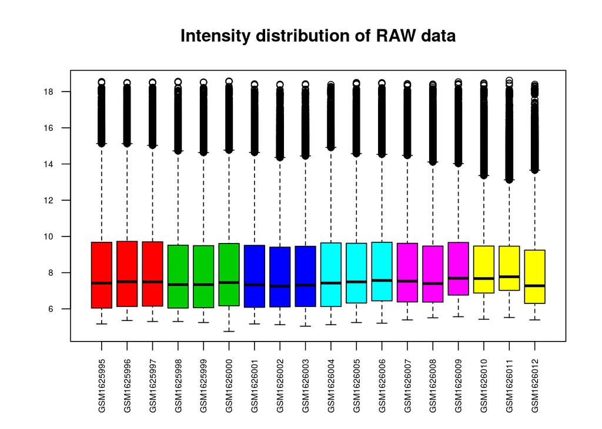

```r
boxplot(rawDataLog, which="all",las=2, main="Intensity distribution of RAW data",
        cex.axis=0.6, col=sampleColor, names=sampleNames)
```

In the boxplot, we can observe that there is a light variation of intensity among arrays, which is the expected for raw data.

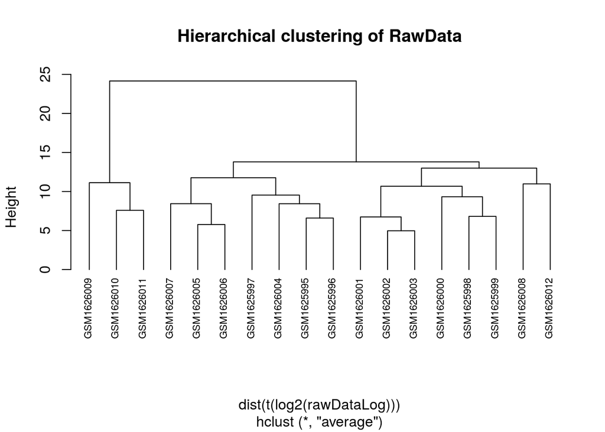

```r
clust.euclid.average <- hclust(dist(t(log2(rawDataLog))),method="average")
plot(clust.euclid.average, labels=sampleNames, main="Hierarchical clustering of RawData",
     cex=0.7,  hang=-1)
```

The hclust function starts with one cluster per sample and clusters iteratively the two most similar ones, until there is a single cluster. The “average” argument specifies UPGMA as the agglomeration method to be used. The final plot shows which samples are more similar between them.

```r
require(ggplot2)
require(ggrepel)

plotPCA3 <- function(X, labels, factor, title, scale, colors, size=1.5, glineas=0.25){
  data <- prcomp(t(X),scale=scale)
  dataDf <- data.frame(data$x)
  Group <- factor
  loads <- round(data$sdev^2/sum(data$sdev^2)*100,1)
  p1 <- ggplot(dataDf,aes(x=PC1, y=PC2)) +
    theme_classic() +
    geom_hline(yintercept = 0, color = "gray70") +
    geom_vline(xintercept = 0, color = "gray70") +
    geom_point(aes(color = Group), alpha = 0.55, size = 3) +
    coord_cartesian(xlim = c(min(data$x[,1])-5,max(data$x[,1])+5)) +
    scale_fill_discrete(name = "Group")
  p1 + geom_text_repel(aes(y = PC2 + 0.25, label = labels), segment.size = 0.25, size = size) +
    labs(x = c(paste("PC1",loads[1],"%")), y = c(paste("PC2", loads[2], "%"))) +
    ggtitle(paste("Principal Component Analysis for: ", title, sep=" ")) +
    scale_color_manual(values=colors)
}
```

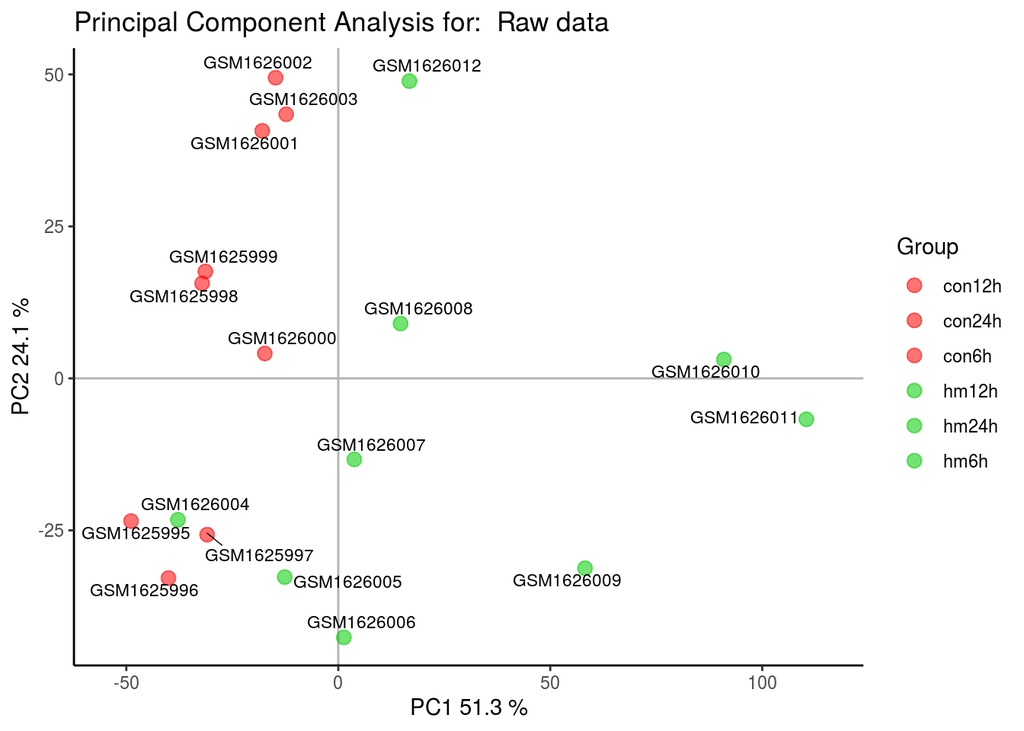

```r
plotPCA3(rawDataLog, labels = targets$sampleName, factor = targets$Group, title = "Raw data", scale = FALSE, size = 3, colors = targets$Color)
```

The 51.3% of the total variability of the samples is explained by the first component of the PCA. The main contribution of this variability is the fact that whether the samples are infected or not (controls), as the control samples are found on the left section of the graph, while the infected samples are mainly found on the right section.

## Data normalization

Once we have assessed the quality of the raw data, we will normalize it in order to make the arrays comparable among them and to reduce the noise caused by external factors than the ones considered in the experiment. With the data normalized, then, we will be able to proceed to the differential expression analysis.

As our raw data contains control and duplicated probes, we are going to filter first the data.

```r
control <- rawData$genes$ControlType==1
filteredData <- rawData[!control,]
dup <- duplicated(filteredData$genes$ProbeName)
filteredData <- filteredData[!dup,]
```

The normalization process is done in three steps: background correction, normalization and summarization.

```r
bg.set <- limma::backgroundCorrect(filteredData, method = "normexp")
```

```
## Array 1 corrected
## Array 2 corrected
## Array 3 corrected
## Array 4 corrected
## Array 5 corrected
## Array 6 corrected
## Array 7 corrected
## Array 8 corrected
## Array 9 corrected
## Array 10 corrected
## Array 11 corrected
## Array 12 corrected
## Array 13 corrected
## Array 14 corrected
## Array 15 corrected
## Array 16 corrected
## Array 17 corrected
## Array 18 corrected
```

```r
nset <- normalizeBetweenArrays(bg.set, method = "quantile")
```

## Building the ExpressionSet

From the normalized data, now we are able to build an ExpressionSet, which will be useful for proceeding with the analysis and having acces to more functions.

```r
expressions <- data.frame(nset$E, row.names = nset$genes$ProbeName)
genes <- t(expressions)[0,]

#AssayData
require(Biobase)
expressions <- as.matrix(expressions)
eset <- ExpressionSet(expressions)

#Information about covariates
columnDesc <-  data.frame(labelDescription= c("File Name", "Sample Name", "Group", "Replicate", "Color"))
annot <- new("AnnotatedDataFrame", data=targets, varMetadata= columnDesc)

rownames(pData(annot))<-pData(annot)$sampleName
eset <- ExpressionSet(assayData=expressions, phenoData=annot)

#Information about features
eset <- ExpressionSet(assayData=expressions, phenoData=annot, featureNames =genes)
show(eset)
```

```
## ExpressionSet (storageMode: lockedEnvironment)
## assayData: 41001 features, 18 samples
##   element names: exprs
## protocolData: none
## phenoData
##   sampleNames: GSM1625995 GSM1625996 ... GSM1626012 (18 total)
##   varLabels: FileName sampleName ... Color (5 total)
##   varMetadata: labelDescription
## featureData: none
## experimentData: use 'experimentData(object)'
## Annotation:
```

## Quality control of normalized data

Now that the normalization is done and that we have build an expression set from it, we will perform another quality control to assess how does the normalized data look.

As now an expression set has been build, it is possible to use the function arrayQualityMetrics to perform a complete quality control. The results will be sotred in the “results” directory.

```r
require(arrayQualityMetrics)
arrayQualityMetrics(eset, outdir = file.path(resultsDir, "QCDir.Normalized"), force=TRUE)
```

[output not shown]

All the result obtained with the arrayQualityMetrics indicate that the data has been properly normalized and that there are no potential problems, so the it is possible to proceed with the analysis

The same plots as before has also been done. Changes in all three can be noticed.

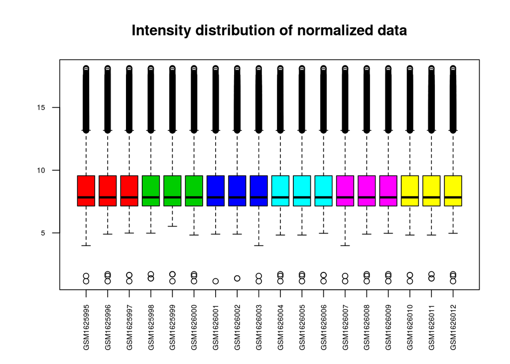

```r
boxplot(exprs(eset), which="all",las=2, main="Intensity distribution of normalized data",
        cex.axis=0.6, col=sampleColor, names=sampleNames)
```

For the boxplot, we can observe that all the boxplots look the same, which may indicate that the normalization has been applied properly on the data. These same boxplots are due to the quantile normalization method used in the limma function normalizeBetweenArrays.

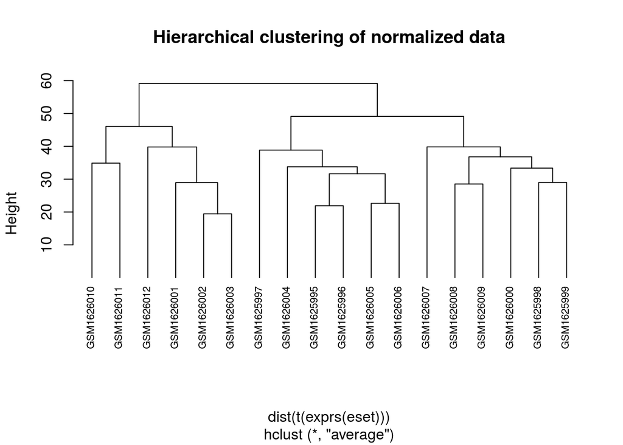

```r
clust.euclid.average <- hclust(dist(t(exprs(eset))),method="average")
plot(clust.euclid.average, labels=sampleNames, main="Hierarchical clustering of normalized data",
     cex=0.7,  hang=-1)
```

The clustering of the normalized data is different than the one for the raw data.

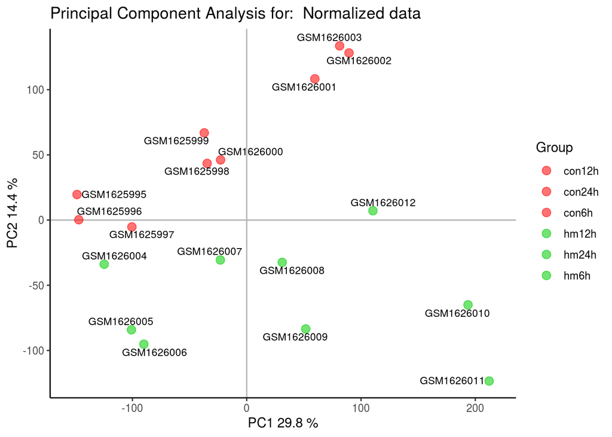

```r
plotPCA3(exprs(eset), labels = targets$sampleName, factor = targets$Group, title = "Normalized data", scale = T, size = 3, colors = targets$Color)
```

The first component now accounts for the 29.8% of the total variability; the percentage is less than for the first component on raw data. Now, the samples are separated differently. The infected ones are in the bottom section, whereas the controls are found above. If we examine each of the samples closer, we find that the samples on the left correspond to hours 6h and 12h for the controls and hour 6h for the infected (except for one 12h replicate that is also on the left), and the samples on the right to hour 24h for the controls and hours 12h and 24h for the infected.

## Detecting most variable genes

The selection of the most variable genes will depend on the total number of genes considered for the analysis. In order to make a first general detection, an approach is to plot the variability of all genes and identify which present a highest standard deviation, assumed to be due to external causes and not random variation. We will use as treshold the 95% percentile.

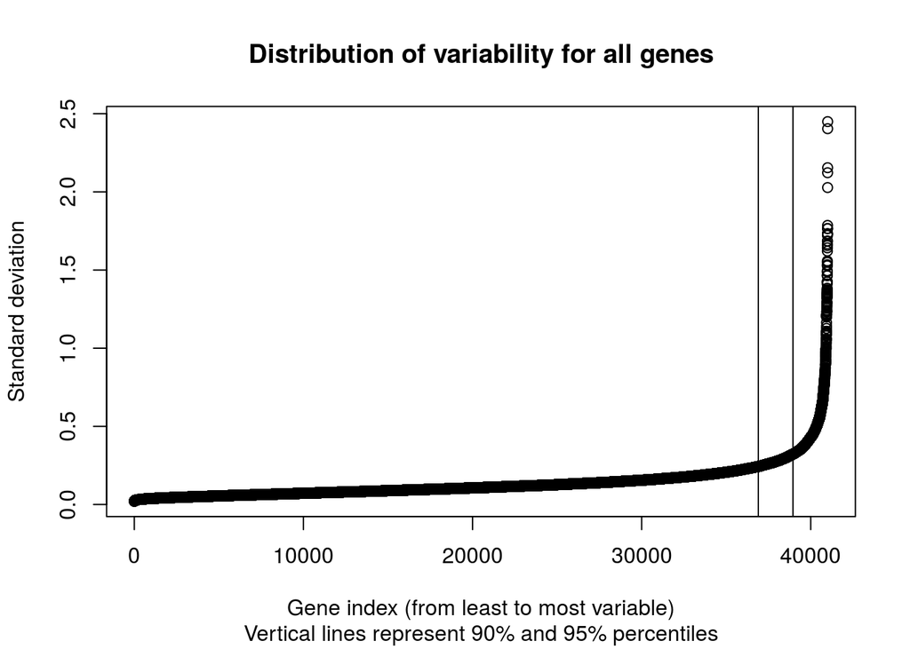

```
## integer(0)
```

```r
sds <- apply(eset, 1, sd)
sdsO<- sort(sds)
plot(1:length(sdsO), sdsO, main="Distribution of variability for all genes",
     sub="Vertical lines represent 90% and 95% percentiles", xlab="Gene index (from least to most variable)",
     ylab="Standard deviation") +
abline(v=length(sds)*c(0.9,0.95))
```

## Filtering least variable genes

In this step, those genes whose variability could be due to random variation and not due to the conditions studied in the experiment are filtered. To do the filtering the package genefilter and function nsFilter are used, based on a variability treshold.

```r
require(genefilter)
require(hgug4112a.db)

annotation(eset) <- "hgug4112a.db"
filtered <- nsFilter(eset, require.entrez = TRUE, remove.dupEntrez = TRUE, var.filter = TRUE, var.func = IQR, var.cutoff = 0.75, filterByQuantile = TRUE, feature.exclude = "^AFFX")

print(filtered$filter.log)
```

```
## $numDupsRemoved
## [1] 10873
##
## $numLowVar
## [1] 14125
##
## $numRemoved.ENTREZID
## [1] 11294
```

By removing the least variable genes, the filtered set is obtained.

```r
eset_filtered <- filtered$eset
```

## The design matrix

To select the differentially expressed genes, many approaches can be used. Here, the Linear Models for Microarrays method, implemented in the limma package, is going to be used. In the first step for this method, a design matrix is created; it relates each sample to a different group. In this case, we have two main groups (control, infected) and three sub-groups per each one, corresponding to the time points (6h, 12h, 24h).

The design matrix is defined using the factor variable “Group” previously included in the targets file. The row samples belonging to the column group are indicated with a 1.

```r
treat <- targets$Group
lev <- factor(treat, levels = unique(treat))
design <-model.matrix(~0+lev)
colnames(design) <- levels(lev)
rownames(design) <- targets$sampleName
print(design)
```

```
##            con6h con12h con24h hm6h hm12h hm24h
## GSM1625995     1      0      0    0     0     0
## GSM1625996     1      0      0    0     0     0
## GSM1625997     1      0      0    0     0     0
## GSM1625998     0      1      0    0     0     0
## GSM1625999     0      1      0    0     0     0
## GSM1626000     0      1      0    0     0     0
## GSM1626001     0      0      1    0     0     0
## GSM1626002     0      0      1    0     0     0
## GSM1626003     0      0      1    0     0     0
## GSM1626004     0      0      0    1     0     0
## GSM1626005     0      0      0    1     0     0
## GSM1626006     0      0      0    1     0     0
## GSM1626007     0      0      0    0     1     0
## GSM1626008     0      0      0    0     1     0
## GSM1626009     0      0      0    0     1     0
## GSM1626010     0      0      0    0     0     1
## GSM1626011     0      0      0    0     0     1
## GSM1626012     0      0      0    0     0     1
## attr(,"assign")
## [1] 1 1 1 1 1 1
## attr(,"contrasts")
## attr(,"contrasts")$lev
## [1] "contr.treatment"
```

## The contrast matrix

The comparisons between groups in which we are interested are:

That is, the control group compared with the infected group at different time points. Also, the infected group at the final stage (24h) compared with the first stage (6h).

The contrast matrix defines these comparisons.

```r
require(limma)
cont.matrix <- makeContrasts (
  hm6vscon6 = hm6h-con6h,
  hm12vscon12 = hm12h-con12h,
  hm24vscon24 = hm24h-con24h,
  hm24vshm6 = hm24h-hm6h,
  levels=design)
print(cont.matrix)
```

```
##         Contrasts
## Levels   hm6vscon6 hm12vscon12 hm24vscon24 hm24vshm6
##   con6h         -1           0           0         0
##   con12h         0          -1           0         0
##   con24h         0           0          -1         0
##   hm6h           1           0           0        -1
##   hm12h          0           1           0         0
##   hm24h          0           0           1         1
```

## Model estimation

Once we have defined the deign and contrast matrices, the next step is to estimate the model, which will be used to perform the tests and see if there is any significance differential expression.

The limma package uses Empirical Bayes models to estimate variability based on both overall matrix and individuals. The result is stored in a MArrayLM object.

```r
fit<-lmFit(eset, design)
fit.main<-contrasts.fit(fit, cont.matrix)
fit.main<-eBayes(fit.main)
```

## Differentially Expressed Genes

In this step, we order the genes from smallest to highest p-value for each of the comparisons. The genes with smallest p-value are considered the most differentially expressed, whether those with a higher p-value are considered less differentially expressed.

```r
topTab_hm6vscon6 <- topTable(fit.main, number=nrow(fit.main), coef="hm6vscon6", adjust="fdr")
tt1 <- head(topTab_hm6vscon6)

topTab_hm12vscon12 <- topTable(fit.main, number=nrow(fit.main), coef="hm12vscon12", adjust="fdr")
tt2 <-head(topTab_hm12vscon12)

topTab_hm24vscon24  <- topTable(fit.main, number=nrow(fit.main), coef="hm24vscon24", adjust="fdr")
tt3 <- head(topTab_hm24vscon24)

topTab_hm24vshm6  <- topTable(fit.main, number=nrow(fit.main), coef="hm24vshm6", adjust="fdr")
tt4 <- head(topTab_hm24vshm6)
```

Top table results for hm6vscon6 comparison

|  | logFC | AveExpr | t | P.Value | adj.P.Val | B |
| --- | --- | --- | --- | --- | --- | --- |
| A_23_P106194 | 2.3236401 | 11.271212 | 10.362424 | 0e+00 | 0.0012273 | 8.673303 |
| A_32_P75141 | -0.6247676 | 9.913584 | -9.560247 | 1e-07 | 0.0017761 | 7.809104 |
| A_23_P214080 | 1.2476394 | 12.395597 | 9.188106 | 1e-07 | 0.0018972 | 7.380502 |
| A_24_P926580 | 0.4078421 | 7.883772 | 8.927323 | 2e-07 | 0.0018972 | 7.069117 |
| A_32_P118657 | 0.7895014 | 9.083497 | 8.860423 | 2e-07 | 0.0018972 | 6.987733 |
| A_32_P227724 | 0.5362009 | 7.778885 | 8.201205 | 6e-07 | 0.0033351 | 6.151829 |

Top table results for hm12vscon12 comparison

|  | logFC | AveExpr | t | P.Value | adj.P.Val | B |
| --- | --- | --- | --- | --- | --- | --- |
| A_24_P395814 | -0.4847111 | 10.021499 | -9.699120 | 1e-07 | 0.0010468 | 7.935078 |
| A_32_P99533 | 0.5948907 | 8.374427 | 9.686957 | 1e-07 | 0.0010468 | 7.921658 |
| A_32_P233870 | -0.7708485 | 9.772654 | -9.536016 | 1e-07 | 0.0010468 | 7.753558 |
| A_23_P85441 | -0.5872254 | 9.241881 | -9.440401 | 1e-07 | 0.0010468 | 7.645552 |
| A_24_P843921 | -1.3503608 | 8.197290 | -9.089495 | 2e-07 | 0.0011553 | 7.238828 |
| A_23_P167537 | -0.3388379 | 10.064569 | -9.079819 | 2e-07 | 0.0011553 | 7.227379 |

Top table results for hm24vscon24 comparison

|  | logFC | AveExpr | t | P.Value | adj.P.Val | B |
| --- | --- | --- | --- | --- | --- | --- |
| A_24_P30194 | 1.835445 | 10.417290 | 20.37275 | 0 | 1e-07 | 17.55704 |
| A_23_P24004 | 4.140689 | 10.486889 | 19.63349 | 0 | 1e-07 | 17.14682 |
| A_23_P63668 | 1.638214 | 9.673459 | 18.72180 | 0 | 1e-07 | 16.60891 |
| A_24_P175187 | 1.753256 | 8.342488 | 18.52542 | 0 | 1e-07 | 16.48814 |
| A_23_P384355 | 2.418036 | 8.097307 | 18.47059 | 0 | 1e-07 | 16.45410 |
| A_24_P740662 | 1.459504 | 8.713133 | 17.38344 | 0 | 1e-07 | 15.74888 |

Top table results for hm24vshm6 comparison

|  | logFC | AveExpr | t | P.Value | adj.P.Val | B |
| --- | --- | --- | --- | --- | --- | --- |
| A_23_P19663 | 2.797438 | 11.21559 | 47.61586 | 0 | 0 | 30.18570 |
| A_23_P46426 | 2.433125 | 13.98431 | 41.86148 | 0 | 0 | 28.64405 |
| A_23_P6771 | 2.486685 | 12.90890 | 40.69192 | 0 | 0 | 28.29256 |
| A_32_P140262 | -1.900257 | 10.15721 | -38.13586 | 0 | 0 | 27.47260 |
| A_23_P52017 | -1.832518 | 11.91494 | -38.03431 | 0 | 0 | 27.43846 |
| A_24_P201064 | 1.880707 | 10.68958 | 36.99275 | 0 | 0 | 27.08104 |

To extract results from these top tables, we are going to proceed to gene annotation, which will provide a more accurate insight for deciding which genes can be considered more differentially expressed.

## Gene annotation

Gene annotation will consist on associating the identifiers on the tables with more common gene names, using the Agilent annotation package used for the microarray experiment.

```r
require(hgug4112a.db)
annotatedTopTable <- function(topTab, anotPackage){
  topTab <- cbind(PROBEID=rownames(topTab), topTab)
  myProbes <- rownames(topTab)
  thePackage <- eval(parse(text = anotPackage))
  geneAnots <- select(thePackage, myProbes, c("SYMBOL", "ENTREZID", "GENENAME"))
  annotatedTopTab <- merge(x=geneAnots, y=topTab, by.x="PROBEID", by.y="PROBEID")
  return(annotatedTopTab)
}
```

In this case, the annotated top tables show four columns: PROBEID, SYMBOL; ENTREZID and GeneName.

```r
topAnnotated_hm6vscon6 <- annotatedTopTable(topTab_hm6vscon6, anotPackage = "hgug4112a.db")
tta1 <- head(topAnnotated_hm6vscon6[1:6,1:4])

topAnnotated_hm12vscon12 <- annotatedTopTable(topTab_hm12vscon12, anotPackage = "hgug4112a.db")
tta2 <- head(topAnnotated_hm12vscon12[1:6,1:4])

topAnnotated_hm24vscon24 <- annotatedTopTable(topTab_hm24vscon24, anotPackage = "hgug4112a.db")
tta3 <- head(topAnnotated_hm24vscon24[1:6,1:4])

topAnnotated_hm24vshm6 <- annotatedTopTable(topTab_hm24vshm6, anotPackage = "hgug4112a.db")
tta4 <- head(topAnnotated_hm24vshm6[1:6,1:4])
```

Annotated top table results for hm6vscon6 comparison

| PROBEID | SYMBOL | ENTREZID | GENENAME |
| --- | --- | --- | --- |
| (-)3xSLv1 | NA | NA | NA |
| A_23_P100001 | FAM174B | 400451 | family with sequence similarity 174 member B |
| A_23_P100011 | AP3S2 | 10239 | adaptor related protein complex 3 subunit sigma 2 |
| A_23_P100022 | SV2B | 9899 | synaptic vesicle glycoprotein 2B |
| A_23_P100056 | RBPMS2 | 348093 | RNA binding protein, mRNA processing factor 2 |
| A_23_P100074 | AVEN | 57099 | apoptosis and caspase activation inhibitor |

Annotated top table results for hm12vscon12 comparison

| PROBEID | SYMBOL | ENTREZID | GENENAME |
| --- | --- | --- | --- |
| (-)3xSLv1 | NA | NA | NA |
| A_23_P100001 | FAM174B | 400451 | family with sequence similarity 174 member B |
| A_23_P100011 | AP3S2 | 10239 | adaptor related protein complex 3 subunit sigma 2 |
| A_23_P100022 | SV2B | 9899 | synaptic vesicle glycoprotein 2B |
| A_23_P100056 | RBPMS2 | 348093 | RNA binding protein, mRNA processing factor 2 |
| A_23_P100074 | AVEN | 57099 | apoptosis and caspase activation inhibitor |

Annotated top table results for hm24vscon24 comparison

| PROBEID | SYMBOL | ENTREZID | GENENAME |
| --- | --- | --- | --- |
| (-)3xSLv1 | NA | NA | NA |
| A_23_P100001 | FAM174B | 400451 | family with sequence similarity 174 member B |
| A_23_P100011 | AP3S2 | 10239 | adaptor related protein complex 3 subunit sigma 2 |
| A_23_P100022 | SV2B | 9899 | synaptic vesicle glycoprotein 2B |
| A_23_P100056 | RBPMS2 | 348093 | RNA binding protein, mRNA processing factor 2 |
| A_23_P100074 | AVEN | 57099 | apoptosis and caspase activation inhibitor |

Annotated top table results for hm24vshm6 comparison

| PROBEID | SYMBOL | ENTREZID | GENENAME |
| --- | --- | --- | --- |
| (-)3xSLv1 | NA | NA | NA |
| A_23_P100001 | FAM174B | 400451 | family with sequence similarity 174 member B |
| A_23_P100011 | AP3S2 | 10239 | adaptor related protein complex 3 subunit sigma 2 |
| A_23_P100022 | SV2B | 9899 | synaptic vesicle glycoprotein 2B |
| A_23_P100056 | RBPMS2 | 348093 | RNA binding protein, mRNA processing factor 2 |
| A_23_P100074 | AVEN | 57099 | apoptosis and caspase activation inhibitor |

## Visualizing differential expression

To visualize the differential expression, volcano plots can be used. Here, a volcano plot for each comparison has been done. The X-axis can be considered as the “biological effect” and the Y-axis as the “statistical effect”.

```r
geneSymbols <- select(hgug4112a.db, rownames(fit.main), c("SYMBOL"))
SYMBOLS <- geneSymbols$SYMBOL
```

The symbols of the top ten genes in the top tables are shown also in the plots.

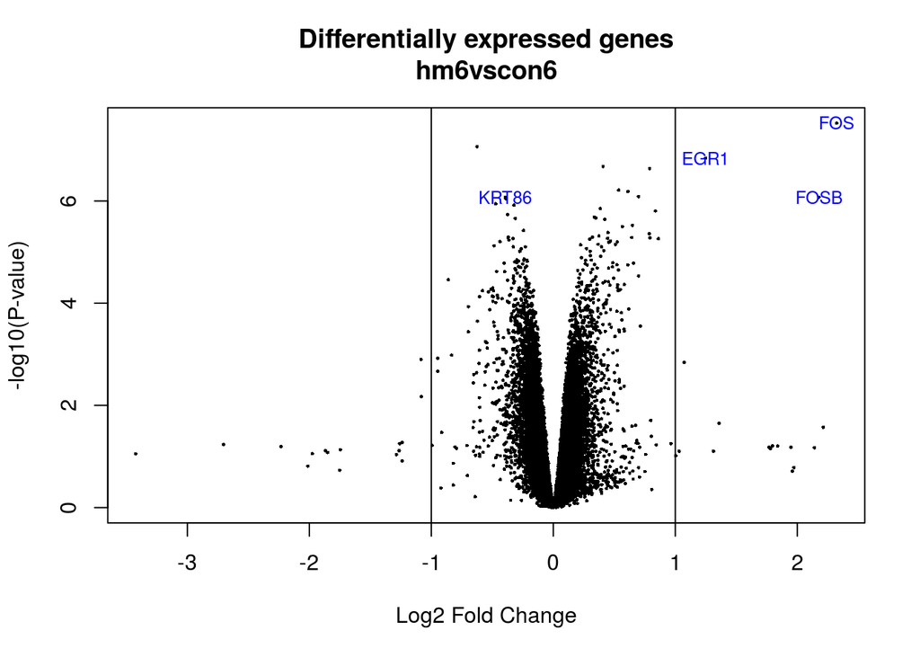

```
## integer(0)
```

```r
volcanoplot(fit.main, coef=1, highlight = 10, names=SYMBOLS, main=paste("Differentially expressed genes", colnames(cont.matrix)[1], sep="\n")) +
abline(v=c(-1,1))
```

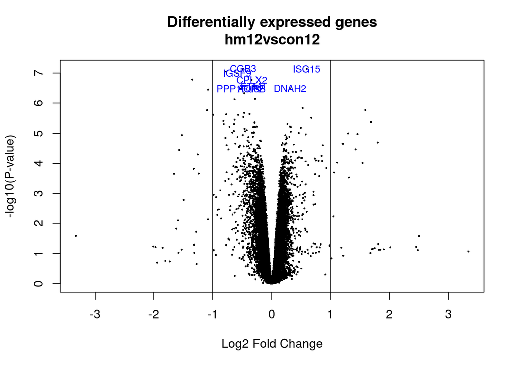

```
## integer(0)
```

```r
volcanoplot(fit.main, coef=2, highlight = 10, names=SYMBOLS, main=paste("Differentially expressed genes", colnames(cont.matrix)[2], sep="\n")) +
abline(v=c(-1,1))
```

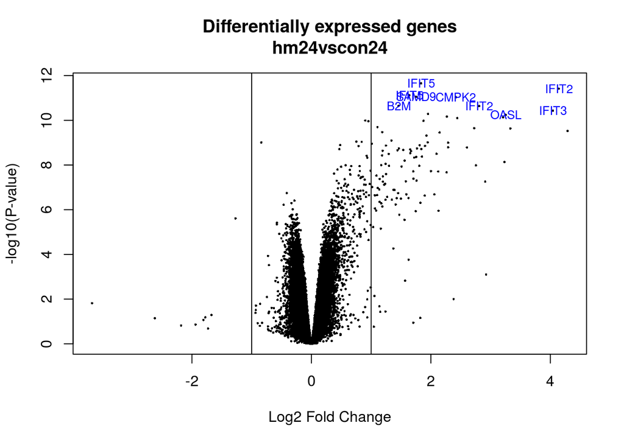

```
## integer(0)
```

```r
volcanoplot(fit.main, coef=3, highlight = 10, names=SYMBOLS, main=paste("Differentially expressed genes", colnames(cont.matrix)[3], sep="\n")) +
abline(v=c(-1,1))
```

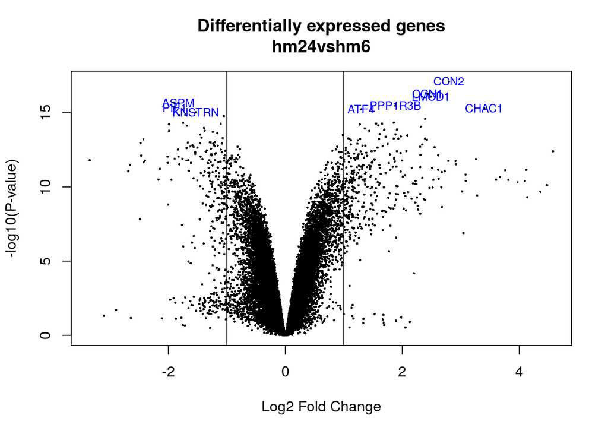

```
## integer(0)
```

```r
volcanoplot(fit.main, coef=4, highlight = 10, names=SYMBOLS, main=paste("Differentially expressed genes", colnames(cont.matrix)[4], sep="\n")) +
abline(v=c(-1,1))
```

## Multiple comparisons

A further step in the analysis of the genes selected for each comparison can be done using a graphical approach, to see which genes and how many are only selected for one comparison, both or all three comparisons.

These can be also be achieved with the the limma package and the functions decideTEsts and VennDiagram.

```r
require(limma)
res <- decideTests(fit.main, method="separate", adjust.method="fdr", p.value=0.1, lfc=1)
sum.res.rows <- apply(abs(res),1,sum)
res.selected <- res[sum.res.rows!=0,]
print(summary(res))
```

```
##        hm6vscon6 hm12vscon12 hm24vscon24 hm24vshm6
## Down           1          10           2       300
## NotSig     40996       40980       40894     40342
## Up             4          11         105       359
```

We see that most genes are not significant, but a few ones are up regulated, and fewer are down regulated. The most relevant comparison in which we observe higher up and downregulation is in the comparison between the stages of the infected cells.

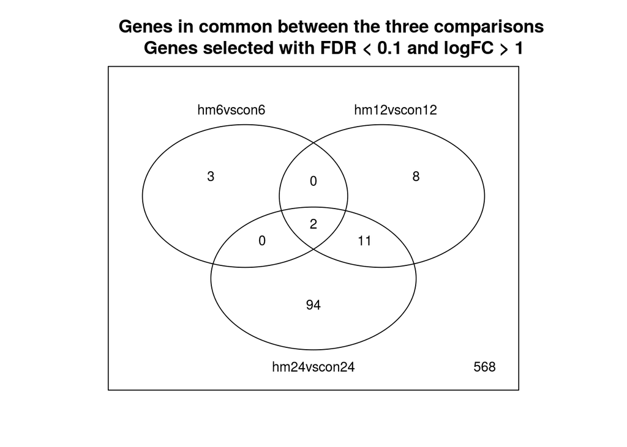

```
## integer(0)
```

```r
vennDiagram(res.selected[,1:3], cex=0.9) +
title("Genes in common between the three comparisons\n Genes selected with FDR < 0.1 and logFC > 1")
```

The three comparisons only share two genes; however, comparisons for 12h and 24h share 11 genes.

## Biological significance of results

The Bioconductor package ReactomePA can provide a first statistical approach for the biological interpretation of the results. It allows to perform a basic enrichment analysis for pathways from a list of genes.

First of all, we are going to prepare the list of genes and the Entrez Identifiers for all the genes analyzed.

```r
listOfTables <- list(hm6vscon6 = topTab_hm6vscon6,
                     hm12vscon12 = topTab_hm12vscon12,
                     hm24vscon24 = topTab_hm24vscon24,
                     hm24vshm6 = topTab_hm24vshm6)
listOfSelected <- list()
i = 1
for (i in 1:length(listOfTables)){
  # select the toptable
  topTab <- listOfTables[[i]]
  # select the genes to be included in the analysis
  whichGenes<-topTab["adj.P.Val"]<0.15
  selectedIDs <- rownames(topTab)[whichGenes]
  # convert the ID to Entrez
  EntrezIDs <- select(hgug4112a.db, selectedIDs, c("ENTREZID"))
  EntrezIDs <- EntrezIDs$ENTREZID
  listOfSelected[[i]] <- EntrezIDs
  names(listOfSelected)[i] <- names(listOfTables)[i]
}
sapply(listOfSelected, length)
```

```
##   hm6vscon6 hm12vscon12 hm24vscon24   hm24vshm6
##        3532        3655       13399       22066
```

```r
EntrezUni <- topAnnotated_hm24vscon24$ENTREZID
```

```r
require(ReactomePA)

listOfData <- listOfSelected[1:4]
comparisonsNames <- names(listOfData)

organism_ <- "human"
universe <- as.character(EntrezUni)

for (i in 1:length(listOfData)){
  data <- listOfData[[i]]
  genesIn <- listOfSelected[[i]]
  comparison <- comparisonsNames[i]
  enrich.result <- enrichPathway(gene = genesIn,
                                 pvalueCutoff = 0.05,
                                 readable = T,
                                 organism =  organism_,
                                 universe = universe,
                                 minGSSize = 10,
                                 maxGSSize = 500,
                                 pAdjustMethod = "BH")

  if (length(rownames(enrich.result@result)) != 0) {
  write.csv(as.data.frame(enrich.result),
             file =paste0("./results/","ReactomePA.Results.",comparison,".csv"),
             row.names = FALSE)

  pdf(file=paste0("./results/","ReactomePABarplot.",comparison,".pdf"))
    print(barplot(enrich.result, showCategory = 15, font.size = 4,
            title = paste0("Reactome Pathway Analysis for ", comparison,". Barplot")))
  dev.off()

  pdf(file = paste0("./results/","ReactomePAcnetplot.",comparison,".pdf"))
    print(cnetplot(enrich.result, categorySize = "geneNum", showCategory = 15,
         vertex.label.cex = 0.75))
  dev.off()
  }
}
```

The complete results, including a csv table, a barplot and a reactomePA plot, have been saved in the “results” directory.

## Summary of the results

Finally, as the last step of this analysis, the results obtained are summarized into a table containing the main pathways enriched.

```r
Tab.react.6 <- read.csv2(file.path("./results/ReactomePA.Results.hm6vscon6.csv"), sep = ",", header = TRUE, row.names = 1)
Tab.react.6.short <- Tab.react.6[1:4, 1:5]

Tab.react.12 <- read.csv2(file.path("./results/ReactomePA.Results.hm12vscon12.csv"), sep = ",", header = TRUE, row.names = 1)
Tab.react.12.short <- Tab.react.12[1:4, 1:5]

Tab.react <- read.csv2(file.path("./results/ReactomePA.Results.hm24vscon24.csv"), sep = ",", header = TRUE, row.names = 1)
Tab.react.short <- Tab.react[1:4, 1:5]

Tab.react.hm <- read.csv2(file.path("./results/ReactomePA.Results.hm24vshm6.csv"), sep = ",", header = TRUE, row.names = 1)
Tab.react.hm.short <- Tab.react.hm[1:4, 1:5]
```

First rows and columns for Reactome results on hm6vscon6 comparison

|  | Description | GeneRatio | BgRatio | pvalue | p.adjust |
| --- | --- | --- | --- | --- | --- |
| R-HSA-201722 | Formation of the beta-catenin:TCF transactivating complex | 25/1272 | 85/9934 | 3.87889162826638e-05 | 0.0478894798754977 |
| R-HSA-9018519 | Estrogen-dependent gene expression | 35/1272 | 142/9934 | 8.00513352154515e-05 | 0.0478894798754977 |
| R-HSA-194315 | Signaling by Rho GTPases | 83/1272 | 437/9934 | 0.000110514184328072 | 0.0478894798754977 |
| NA | NA | NA | NA | NA | NA |

First rows and columns for Reactome results on hm12vscon12 comparison

|  | Description | GeneRatio | BgRatio | pvalue | p.adjust |
| --- | --- | --- | --- | --- | --- |
| R-HSA-909733 | Interferon alpha/beta signaling | 24/1182 | 63/9934 | 8.07010064995289e-08 | 0.000103620092345395 |
| R-HSA-913531 | Interferon Signaling | 45/1182 | 191/9934 | 4.12752203593659e-06 | 0.00264986914707129 |
| NA | NA | NA | NA | NA | NA |
| NA.1 | NA | NA | NA | NA | NA |

First rows and columns for Reactome results on hm24vscon24 comparison

|  | Description | GeneRatio | BgRatio | pvalue | p.adjust |
| --- | --- | --- | --- | --- | --- |
| R-HSA-909733 | Interferon alpha/beta signaling | 51/4316 | 63/9934 | 1.05967913348284e-09 | 1.47507335380811e-06 |
| R-HSA-913531 | Interferon Signaling | 120/4316 | 191/9934 | 4.17347554672812e-08 | 2.90473898052277e-05 |
| R-HSA-877300 | Interferon gamma signaling | 60/4316 | 90/9934 | 6.90466653142824e-06 | 0.0032037652705827 |
| NA | NA | NA | NA | NA | NA |

First rows and columns for Reactome results on hm24vshm6 comparison

|  | Description | GeneRatio | BgRatio | pvalue | p.adjust |
| --- | --- | --- | --- | --- | --- |
| R-HSA-5663220 | RHO GTPases Activate Formins | 120/6790 | 136/9934 | 4.56230226620404e-08 | 6.35984935908843e-05 |
| R-HSA-68877 | Mitotic Prometaphase | 163/6790 | 194/9934 | 4.03529533415534e-07 | 0.000207244706479983 |
| R-HSA-2467813 | Separation of Sister Chromatids | 156/6790 | 185/9934 | 4.46007259282603e-07 | 0.000207244706479983 |
| R-HSA-453274 | Mitotic G2-G2/M phases | 162/6790 | 194/9934 | 9.89846259941302e-07 | 0.000295320267503493 |

We can conclude that there are differentially expressed genes between the control and the infected astorcyte cells, and also between the initial and final stage of the infected astrocytes, which suggest the over-activated interferon signaling in U251 cells infected by H5N1.

# GitHub repository

https://github.com/balpaula/Balcells_Paula-OmicsTechniques